# Tag 6

Semesterticket https://asta.ostfalia.de/index.php/beispiel-seite/

[figure not shown]

```python
import qrcode
qrcode.make('https://asta.ostfalia.de/index.php/beispiel-seite/')
```

## 33

### a)

$x^2 - 3x + 2 = 0$

mit pq-Formel

Zur Erinnerung: Die Gleichung hat die Form $x^2 + px + q = 0$, dann sind die Lösungen $x_{1,2} = -\frac{p}{2}\pm\sqrt{\frac{p^2}{4}-q}$, sofern das Argument der Wurzel nicht negativ ist.

$x_{1,2} = -\frac{-3}{2}\pm\sqrt{\frac{(-3)^2}{4}-2}$

$\Leftrightarrow x_{1,2} = \frac{3}{2}\pm\sqrt{\frac{9}{4}-\frac{8}{4}}$

$\Leftrightarrow x_{1,2} = \frac{3}{2}\pm\sqrt{\frac{1}{4}}$

$\Leftrightarrow x_{1,2} = \frac{3}{2}\pm\frac{\sqrt{1}}{\sqrt{4}}$

$\Leftrightarrow x_{1,2} = \frac{3}{2}\pm\frac{1}{2}$

$x_1 = \frac{4}{2} = 2$

$x_2 = \frac{2}{2} = 1$

### b)

$x^2 + 2x = 3 | -3$

$\Leftrightarrow x^2 + 2x - 3 = 0$

mit pq-Formel

$x_{1,2} = -\frac{2}{2}\pm\sqrt{\frac{2^2}{4}-(-3)}$

$\Leftrightarrow x_{1,2} = -1\pm\sqrt{\frac{4}{4} + 3}$

$\Leftrightarrow x_{1,2} = -1\pm\sqrt{4}$

$\Leftrightarrow x_{1,2} = -1\pm2$

$x_1 = 1$

$x_2 = -3$

### c)

$x^2 - 3x = 3 | -3$

$\Leftrightarrow x^2 - 3x - 3 = 0$

mit pq-Formel

$x_{1,2} = -\frac{-3}{2}\pm\sqrt{\frac{(-3)^2}{4}-(-3)}$

$\Leftrightarrow x_{1,2} = \frac{3}{2}\pm\sqrt{\frac{9}{4}+\frac{12}{4}}$

$\Leftrightarrow x_{1,2} = \frac{3}{2}\pm\sqrt{\frac{21}{4}}$

$\Leftrightarrow x_{1,2} = \frac{3}{2}\pm\frac{\sqrt{21}}{\sqrt{4}}$

$\Leftrightarrow x_{1,2} = \frac{3}{2}\pm\frac{\sqrt{21}}{2}$

$\Leftrightarrow x_{1,2} = \frac{3\pm\sqrt{21}}{2}$

$x_1 = \frac{3+\sqrt{21}}{2}$

$x_2 = \frac{3-\sqrt{21}}{2}$

### d)

$2x^2 - 4 = 2x | -2x$

$\Leftrightarrow 2x^2 - 2x - 4 = 0 |/2$

$\Leftrightarrow x^2 - x - 2 = 0 |/2$

mit pq-Formel

$x_{1,2} = -\frac{-1}{2}\pm\sqrt{\frac{(-1)^2}{4}-(-2)}$

$\Leftrightarrow x_{1,2} = \frac{1}{2}\pm\sqrt{\frac{1}{4}+\frac{8}{4}}$

$\Leftrightarrow x_{1,2} = \frac{1}{2}\pm\sqrt{\frac{9}{4}}$

$\Leftrightarrow x_{1,2} = \frac{1}{2}\pm\frac{\sqrt{9}}{\sqrt{4}}$

$\Leftrightarrow x_{1,2} = \frac{1}{2}\pm\frac{3}{2}$

$x_1 = \frac{4}{2} = 2$

$x_1 = \frac{-2}{2} = -1$

### e)

$9x^2 = 25 | -5$

$\Leftrightarrow 9x^2 -25 = 0 | -5$

Zur Erinnerung: die Gleichung hat die Form $ax^2 + bx + c = 0$, dann sind die Lösungen $x_{1,2} = \frac{-b\pm\sqrt{b^2-4ac}}{2a}$, sofern das Argument der Wurzel nicht legativ ist.

$x_{1,2} = \frac{-0\pm\sqrt{0^2-4*9*(-25)}}{2*9}$

$\Leftrightarrow x_{1,2} = \pm\frac{\sqrt{-4*9*(-25)}}{2*9}$

$\Leftrightarrow x_{1,2} = \pm\frac{\sqrt{4*9*25}}{2*9}$

Weil $2*9$ nicht negativ ist, gilt: $2*9 = \sqrt{(2*9)^2}$

$\Leftrightarrow x_{1,2} = \pm\frac{\sqrt{4*9*25}}{\sqrt{(2*9)^2}}$

$\Leftrightarrow x_{1,2} = \pm\sqrt{\frac{4*9*25}{2*9*2*9}}$

$\Leftrightarrow x_{1,2} = \pm\sqrt{\frac{25}{9}}$

$\Leftrightarrow x_{1,2} = \pm\frac{\sqrt{25}}{\sqrt{9}}$

$\Leftrightarrow x_{1,2} = \pm\frac{5}{3}$

$x_1 = \frac{5}{3}$

$x_2 = -\frac{5}{3}$

### f)

$x^2 + 5x + 10 = 0$

mit pq-Formel

$x_{1,2} = -\frac{5}{2}\pm\sqrt{\frac{5^2}{4}-10}$

$\Leftrightarrow x_{1,2} = -\frac{5}{2}\pm\sqrt{\frac{5}{4}-\frac{40}{4}}$

### g)

$2x^2 - 12x + 18 = 0 | /2$

$\Leftrightarrow x^2 - 6x + 9 = 0$

mit pq-Formel

$x_{1,2} = -\frac{-6}{2}\pm\sqrt{\frac{(-6)^2}{4}-9}$

$\Leftrightarrow x_{1,2} = 3\pm\sqrt{\frac{36}{4}-9}$

$\Leftrightarrow x_{1,2} = 3\pm\sqrt{9-9}$

$\Leftrightarrow x_{1,2} = 3\pm\sqrt{0}$

$\Leftrightarrow x_{1,2} = 3$

## 34

### a)

$x^2 + 12x + 35 = 0$

mit pq-Formel

$x_{1,2} = -\frac{12}{2}\pm\sqrt{\frac{12^2}{4}-35}$

$\Leftrightarrow x_{1,2} = -6\pm\sqrt{\frac{144}{4}-35}$

$\Leftrightarrow x_{1,2} = -6\pm\sqrt{36-35}$

$\Leftrightarrow x_{1,2} = -6\pm\sqrt{1}$

$\Leftrightarrow x_{1,2} = -6\pm1$

$x_1 = -5$

$x_2 = -7$

mit quadratischer Ergänzung (siehe d für eine Erklärung)

$\Leftrightarrow x^2 + 2 * x * 6 + 6^2 - 6^2 + 35 = 0$

$\Leftrightarrow (x + 6)^2 -36 + 35 = 0 | +1$

$\Leftrightarrow (x + 6)^2 = 1$

Gesucht sind nun die beiden Zahlen, der Quadrat $1$ ist. Dies sind $\pm\sqrt{1} = \pm1$. Nun können wir zwei weitere Gleichungen aufstellen:

$x_1 + 6 = 1 | -6$

$x_2 + 6 = -1 | -6$

Es folgt:

$x_1 = -5$

$x_2 = -7$

### b)

$x^2 - 18x + 65 = 0$

mit pq-Formel

$x_{1,2} = -\frac{-18}{2}\pm\sqrt{\frac{(-18)^2}{4}-65}$

$\Leftrightarrow x_{1,2} = 9\pm\sqrt{\frac{(-18)^2}{2^2}-65}$

$\Leftrightarrow x_{1,2} = 9\pm\sqrt{(\frac{-18}{2})^2-65}$

$\Leftrightarrow x_{1,2} = 9\pm\sqrt{(-9)^2-65}$

$\Leftrightarrow x_{1,2} = 9\pm\sqrt{81-65}$

$\Leftrightarrow x_{1,2} = 9\pm\sqrt{16}$

$\Leftrightarrow x_{1,2} = 9\pm4$

$x_1 = 13$

$x_2 = 5$

mit quadratischer Ergänzung (siehe d für eine Erklärung)

$x^2 - 2 * x * 9 + 9^2 - 9^2+ 65 = 0$

$\Leftrightarrow (x - 9)^2 - 81 + 65 = 1 | + 81 - 64 = 16$

$\Leftrightarrow (x - 9)^2 = 16 | \sqrt{.}$

$\Leftrightarrow |x - 9| = \sqrt{16}$

$\Leftrightarrow \pm(x_{1,2} - 9) = 4 | * (\pm1)$

$\Leftrightarrow x_{1,2} - 9 = \pm4 | + 9$

$\Leftrightarrow x_{1,2} = \pm4 + 9$

$x_1 = 13$

$x_2 = 5$

### c)

$x^2 - 4x + 21 = 0$

mit pq-Formel

$x_{1,2} = -\frac{-4}{2}\pm\sqrt{\frac{(-4)^2}{4}-21}$

$\Leftrightarrow x_{1,2} = 2\pm\sqrt{\frac{16}{4}-21}$

$\Leftrightarrow x_{1,2} = 2\pm\sqrt{4-21}$

$\Leftrightarrow x_{1,2} = 2\pm\sqrt{-17}$

$\sqrt{-17}$ ist keine reelle Zahl (weil das Argument der Wurzel negativ ist). Daher gibt es keine reellen Lösungen.

mit quadratischer Ergänzung (siehe d für eine Erklärung)

$x^2 - 2 * x * 2 + 2^2 - 2^2 + 21 = 0$

$\Leftrightarrow (x - 2)^2 - 4 + 21 = 0 | + 4 - 21 = -17$

$\Leftrightarrow (x - 2)^2 = -17$

Quadrate von (reellen) Zahlen sind nie negativ. Damit gibt es keine Lösung.

### d)

$4x^2+56x+1960=0 | /4$

$\Leftrightarrow x^2 + 14 x + 490 = 0$

Mittels quadratischer Ergänzung: $a^2 + 2ab + b^2 = (a + b)^2$ $x$ soll im $a$-Term vorkommen. Daher suchen wir in der Gleichung nach einem Summanden mit $x^2$. Dieser ist ohne weitere Faktoren vorhanden. Daher $a = x$. Aus $a^2 + 2ab + b^2 = (a + b)^2$ folgt nun $x^2 + 2xb + b^2 = (x + b)^2$. Wir suchen nun nach einem Kandidaten für $2ab$ bzw. $2xb$. Dafür kommt nur $14x$ in Frage.

$14x = 2xb | 2x$ (O.B.d.A. (Ohne Beschränkung der Allgemeinheit) $x \neq 0$, weil die Gleichung für ein beliebiges $x$ gelten soll.)

$\Leftrightarrow 7 = b$

Dies wird nun ebenfalls eingesetzt:

$x^2 + 2x7 + 7^2 = (x + 7)^2$

$x^2 + 2x7 + 49 = (x + 7)^2$

Für unsere Gleichung passt der Summand ohne $x$ noch nicht. Daher wird $+ 490 - 49$ gerechnet

$x^2 + 2x7 + 49 + 490 - 49 = (x + 7)^2 + 490 - 49$

$\Leftrightarrow x^2 + 2x7 + 490 = (x + 7)^2 + 490 - 49$

Wir erhalten also:

$(x + 7)^2 + 441 = 0 | - 411$

$\Leftrightarrow (x + 7)^2 = -411$

Es gibt keine Lösungen, weil das Quadrat nicht negativ sein kann.

Eine kürzere Schreibweise wäre diese:

$\Leftrightarrow x^2 + 2*x*7 + (7)^2 + (490 - 49) = 0$

Die Schritte der Quadratischen ergänzung sind hier weniger ausführlich geschrieben, weil die werte soweit abgelesen werden können.

### e)

$4x^2 + 62x + 323 = -10x - 1 | +10x + 1$

$\Leftrightarrow 4x^2 + 72x + 324 = 0$

Mittels quadratischer Ergänzung

Nebenrechnung $\frac{72}{2*2} = 18$

$\Leftrightarrow (2x)^2 + 2 * (2x) * 18 + 18^2 + (324 - 18^2) = 0$

$\Leftrightarrow (2x + 18)^2 + (324 - 18^2) = 0$

$\Leftrightarrow (2x + 18)^2 + (324 - 324) = 0$

$\Leftrightarrow (2x + 18)^2 = 0$

Es gibt nur eine (doppelte) Lösung, nämlich dann, wenn $2x + 18 = 0$ gilt.

$2x_{1,2} + 18 = 0 | -18$

$\Leftrightarrow 2x_{1,2} = -18 | /2$

$\Leftrightarrow x_{1,2} = -9$

### f)

$(2x + 1)^2 = -44x - 127$

$\Leftrightarrow 4x^2 + 4x + 1 = -44x -127 | + 44x + 127$

$\Leftrightarrow 4x^2 + 48x + 128 = 0$

Mittels quadratischer Ergänzung

Nebenrechnung $\frac{48}{2*2} = 12$

$\Leftrightarrow (2x)^2 + 2 * (2x) * 12 + 12^2 - 12^2 + 128 = 0$

$\Leftrightarrow (2x + 12)^2 - 144 + 128 = 0 | + 144 - 128$

$\Leftrightarrow (2x + 12)^2 = 16 |\sqrt{.}$

$\Leftrightarrow 2x_{1,2} + 12 = \pm\sqrt{16}$

$\Leftrightarrow 2x_{1,2} + 12 = \pm4 | - 12$

$\Leftrightarrow 2x_{1,2} = \pm4 - 12 | / 2$

$\Leftrightarrow x_{1,2} = \pm2 - 6$

$x_1 = -4$

$x_2 = -8$

### g)

$x^2 - 9x + 18 = 0$

Mittels quadratischer Ergänzung

$\Leftrightarrow x^2 - 2 * x * \frac{9}{2} + (\frac{9}{2})^2 - (\frac{9}{2})^2 + 18 = 0$

$\Leftrightarrow (x - \frac{9}{2})^2 - \frac{9^2}{2^2} + 18 = 0$

$\Leftrightarrow (x - \frac{9}{2})^2 - \frac{81}{4} + \frac{4*18}{4} = 0$

$\Leftrightarrow (x - \frac{9}{2})^2 - \frac{81}{4} + \frac{72}{4} = 0 | + \frac{81}{4} - \frac{72}{4} = \frac{9}{4}$

$\Leftrightarrow (x - \frac{9}{2})^2 = \frac{9}{4} | \sqrt{.}$

$\Leftrightarrow x_{1,2} - \frac{9}{2} = \pm\sqrt{\frac{9}{4}}$

$\Leftrightarrow x_{1,2} - \frac{9}{2} = \pm\frac{\sqrt{9}}{\sqrt{4}}$

$\Leftrightarrow x_{1,2} = \frac{\pm3}{2} | + \frac{9}{2}$

$\Leftrightarrow x_{1,2} = \frac{\pm3 + 9}{2}$

$x_1 = \frac{3 + 9}{2} = 6$

$x_2 = \frac{-3 + 9}{2} = 3$

### h)

$x^2 - 13x + 40 = 0$

Mittels quadratischer Ergänzung

$x^2 - 2 * x * \frac{13}{2} + (\frac{13}{2})^2 - (\frac{13}{2})^2 + 40 = 0$

$\Leftrightarrow (x - \frac{13}{2})^2 - \frac{13^2}{2^2} + 40 = 0$

$\Leftrightarrow (x - \frac{13}{2})^2 - \frac{169}{4} + \frac{160}{4} = 0 | + \frac{169}{4} - \frac{160}{4} = \frac{9}{4}$

$\Leftrightarrow (x - \frac{13}{2})^2 = \frac{9}{4} | \sqrt{.}$

$\Leftrightarrow x_{1,2} - \frac{13}{2} = \pm\frac{\sqrt{9}}{\sqrt{4}} | + \frac{13}{2}$

$\Leftrightarrow x_{1,2} = \frac{\pm3}{2} + \frac{13}{2}$

$\Leftrightarrow x_{1,2} = \frac{\pm3 + 13}{2}$

$x_1 = \frac{3 + 13}{2} = 8$

$x_2 = \frac{-3 + 13}{2} = 5$

### i)

$x^2 + 7x + 29 = 0$

Mittels quadratischer Ergänzung

$x^2 + 2 * x * \frac{7}{2} + (\frac{7}{2})^2 - (\frac{7}{2})^2 + 29 = 0$

$\Leftrightarrow (x + \frac{7}{2})^2 - \frac{7^2}{2^2} + 29 = 0$

$\Leftrightarrow (x + \frac{7}{2})^2 - \frac{49}{4} + \frac{4*29}{4} = 0 | + \frac{49}{4} - \frac{4*29}{4} = \frac{49 - 116}{4} = \frac{-67}{4}$

$\Leftrightarrow (x + \frac{7}{2})^2 = -\frac{67}{4}$

Keine (reelle) Lösung

### j)

$-2x^2 - 34x - 140 = 0 | / (-2)$

$\Leftrightarrow x^2 + 17x + 70 = 0$

Mittels quadratischer Ergänzung

$\Leftrightarrow x^2 + 2 * x * \frac{17}{2} + (\frac{17}{2})^2 - (\frac{17}{2})^2 + 70 = 0$

$\Leftrightarrow (x + \frac{17}{2})^2 - \frac{17^2}{2^2} + \frac{4*70}{4} = 0 | + \frac{17^2}{2^2} - \frac{4*70}{4} = \frac{289 - 280}{4} = \frac{9}{4}$

$\Leftrightarrow (x + \frac{17}{2})^2 = \frac{9}{4} | \sqrt{.}$

$\Leftrightarrow x_{1,2} + \frac{17}{2} = \pm\sqrt{\frac{9}{4}} | - \frac{17}{2}$

$\Leftrightarrow x_{1,2} = \frac{\pm3}{2} - \frac{17}{2}$

$\Leftrightarrow x_{1,2} = \frac{\pm3 - 17}{2}$

$x_1 = \frac{3 - 17}{2} = -7$

$x_1 = \frac{-3 - 17}{2} = -10$

### k)

$-7x^2 - 128x - 500 = -9x + 4 | + 9x - 4$

$\Leftrightarrow -7x^2 - 119x - 504 = 0 | /(-7)$

$\Leftrightarrow x^2 + 17x + 72 = 0$

Mittels quadratischer Ergänzung

$\Leftrightarrow x^2 + 2 * x * \frac{17}{2} + (\frac{17}{2})^2 - (\frac{17}{2})^2 + 72 = 0$

$\Leftrightarrow (x + \frac{17}{2})^2 - \frac{17}{2}^2 + \frac{4*72}{4} = 0 | + \frac{289 - 288}{4}$

$\Leftrightarrow (x + \frac{17}{2})^2 = \frac{1}{4} | \sqrt{.}$

$\Leftrightarrow x_{1,2} + \frac{17}{2} = \pm\frac{1}{2} | - \frac{17}{2}$

$\Leftrightarrow x_{1,2} = \frac{\pm1-17}{2}$

$x_1 = -8$

$x_1 = -9$

### l)

$(2x + 5)(2x - 5) = -60x - 241$

$4x^2 - 25 = -60x - 241 | +60x + 241$

$4x^2 + 60x + 216 = 0$

Quadratische Ergänzung. Als Erinnerung $(a+b)^2 = a^2 + 2ab + b^2$. Wir wählen $a = 2x$. Es folgt: $2ab = 2 * 2x * b$, was gleich $60x$ sein soll. Dafür eine Nebenrechnung: $2 * 2x * b = 60x | :4x \Leftrightarrow b = 60 / 4$.

$(2x)^2 + 2* 2x *\frac{60}{4} + (\frac{60}{4})^2 - (\frac{60}{4})^2 + 216 = 0$

$(2x)^2 + 2* 2x *\frac{60}{4} + (\frac{60}{4})^2$ Ergibt sich durch die Quadratische Ergänzung. Hierraus kann die I. Binomische Formel angewendet werden. Da wir $(\frac{60}{4})^2$ adiert haben, ziehen wir es auch wieder ab, damit effektiv null addiert wurde. Zuletzt noch $+216$. Nun wird die Binomische Formel angewendet und der rest auf die rechte Seite umgeformt: $-(\frac{60}{4})^2 + 216 = -15^2 + 216 = -225 + 216 = -9$.

$(2x + 15)^2 = 9$

$3$ und $-3$ ergbene im Quadrat $9$. Aus der linken Seite können die diese beiden Gleichungen abgelesen werden:

$2*x + 15 = 3$

$2*x + 15 = -3$

$2*x= -12$

$2*x = -18$

Wir erhalten die Lösungen:

$x= -6$

$x = -9$

# 4.1

## 1

Allgemeines Vorgenen: Die Funktionen sind als verschiebung einer Parabel angegeben. Der Scheitelpunkt der Parabel ist daher ausschlaggebend. Genauer noch, es reicht die y-Komponente. Dise entspricht aber Wert, um den verschoben wurde. Es ist also ausreichen $y \geq n$ zu testen.

### a)

Nein. $0 < 1$

### b)

Ja. $-2 \geq -3$

### c)

Ja. $1 \geq -1$

### d)

Nein. $-\frac{3}{2} < -\frac{1}{2}$

### e)

Nein. $0.2 < 0.4$

## 2

### a)

$x^5 = 3x^3$

$\Leftrightarrow x^5 - 3x^3 = 0$

$\Leftrightarrow x^3(x^2 - 3) = 0$

$\Leftrightarrow x*x*x*(x^2 - 3) = 0$

Damit das gilt, muss einer der Faktoren null sein. Daher gilt: $x_{1,2,3} = 0$ durch die ersten drei Faktoren.

Sollte der letzte null sein, gilt:

$x^2 - 3 = 0 | +3$

$\Leftrightarrow x^2 = 3 |\sqrt{(.)}$

$\Leftrightarrow x_{4,5} = \pm\sqrt{3}$

$L=\{0, -\sqrt{3}, \sqrt{3}\}$

### b)

$x^3 + 6x^2 = 2x | -2x$

$x^3 + 6x^2 - 2x = 0$

$x(x^2 + 6x -2) = 0$

Erste Lösung ist $x_1=0$, aus der Gleichung abgelesen.

Die anderen Beiden werden mit p-q-Formel ermittelt:

$x_2 = -\frac{6}{2}+\sqrt{(\frac{6}{2})^2 - (-2)} = -3+\sqrt{9 + 2} = -3 + \sqrt{11}$

$x_3 = -3-\sqrt{11}$

$L=\{0, -3-\sqrt{11}, -3+\sqrt{11}\}$

## 3

Aus dem Faktorisieren Polynom, wo jeder Factor höchstens den Grad eins hat und der Factor für x eins ist, können die Nullstellen abgelesen werden. Kommt ein Factor doppelt vor, so ist es eine doppelte Nullstelle. Bei quadratischen Gleichungen gibt es dann nur eine.

### a)

$f(x) = (x-1)(x+a)$

Die Faktoren müssen gleich sein.

$x - 1 = x + a | - x$

$\Leftrightarrow -1 = a$

Andere Möglichkeit ist, die Diskriminante (Term unter der Wurzel bei p-q Formel) gleich $0$ zu setzen:

$(x-1)(x+a)$

$\Leftrightarrow x^2 +ax -x -a = 0$

$\Leftrightarrow x^2 +(a-1)x -a = 0$

$-\frac{a-1}{2}\pm\sqrt{\frac{(a-1)^2}{4}+a}$

$\frac{(a-1)^2}{4}+a = 0|*4$

$\Leftrightarrow (a-1)^2+4a = 0$

$\Leftrightarrow a^2-2a+1+4a = 0$

$\Leftrightarrow a^2+2a+1 = 0$

$\Leftrightarrow (a + 1)^2 = 0|\sqrt{(.)}$

$\Leftrightarrow a + 1 = 0$

$\Leftrightarrow a = -1$

### b)

$f(x) = (x + 12)(3x - a) = 3(x + 12)(x - \frac{a}{3})$

$x + 12 = x - \frac{a}{3} | - x$

$\Leftrightarrow 12 = - \frac{a}{3} | * (-3)$

$\Leftrightarrow -36 = a$

### c)

$f(x) = 2(x + 2)(2x - a) = 4(x + 2)(x - \frac{a}{2})$

$x + 2 = x - \frac{a}{2}$

$2 = -\frac{a}{2} | *(-2)$

$-4 = a$

## 4

### a)

Eine Gerade Zahl wird als $2n$ Modelliert, wobei $n$ eine ganze Zahl ist. Der Unterschied zweiter benachbarter geraden Zahlen ist 2. Daher ist die zweite Zahl (o.B.d.A.) $2n + 2$.

$\frac{1}{2n}-\frac{1}{2n + 2} = \frac{1}{24}$

Kleinstes gemeinsames Vielfaches von $2n$, $2n + 2 = 2(n+1)$ und $24 = 2*12$ ist $2n(n+1)*12$

$\Leftrightarrow \frac{1}{2n}-\frac{1}{2n + 2} = \frac{1}{24} | * 2n(n+1)*12$

$\Leftrightarrow (n+1)*12-n*12 = n(n+1)$

$\Leftrightarrow n*12+12-n*12 = n^2 + n | -12$

$\Leftrightarrow 0 = n^2 + n - 12$

$\Leftrightarrow n_{1,2} = -\frac{1}{2} \pm\sqrt{\frac{1}{4} + 12}$

$\Leftrightarrow n_{1,2} = -\frac{1}{2} \pm\sqrt{\frac{49}{4}}$

$\Leftrightarrow n_{1,2} = -\frac{1}{2} \pm\frac{7}{2}$

$n_1 = 3$

$n_2 = -4$

Somit gibt es zwei Lösungen: $2*3 = 6$, $8$ und $2*(-4) = -8$, $-6$

### b)

$\frac{a}{b} = \frac{2}{3}$

$a^2 + b^2 = 208$

Aus der ersten Gleichung folgt, dass keine der beiden Zahlen null sein kann.

$\frac{a}{b} = \frac{2}{3} | * b$

$\Leftrightarrow a = \frac{2b}{3}$

einsetzen

$(\frac{2b}{3})^2 + b^2 = 208$

$\Leftrightarrow \frac{4b^2}{9} + \frac{9b^2}{9} = 208$

$\Leftrightarrow \frac{4b^2 + 9b^2}{9} = 208$

$\Leftrightarrow \frac{13b^2}{9} = 208 |/13 * 9$

$\Leftrightarrow b^2 = 16 * 9$

$\Leftrightarrow b^2 = 144 | \sqrt{.}$

$\Leftrightarrow b_{1,2} = \pm12$

Die beiden Zahlenpaare sind, $12, 8$ und $-12, -8$.

### c)

$a * b = 48$

$10a + b + 18 = 10b + a$ mit $z = 10a + b; a \in \{0, 1, .., 9\}; b \in \{0, 1, .., 9\}$

$10a + b + 18 = 10b + a$

$\Leftrightarrow 10a + b + 18 = 10b + a | -b - 18 - a$

$\Leftrightarrow 9a = 9b - 18 | /9$

$\Leftrightarrow a = b - 2$

einsetzen

$(b - 2) * b = 48 | - 48$

$\Leftrightarrow b^2 - 2b - 48 = 0$

$\Leftrightarrow b_{1,2} = -\frac{-2}{2}\pm\sqrt{\frac{(-2)^2}{4}-(-48)}$

$\Leftrightarrow b_{1,2} = 1\pm\sqrt{49}$

$\Leftrightarrow b_{1,2} = 1\pm7$

$b_1 = 8$, Die Zahl lautet $68$

$b_2 = -6$, Keine Lösung, da $-6 \notin \{0, 1, .., 9\}$

### d)

$z = 10a + b; a \in \{0, 1, .., 9\}; b \in \{0, 1, .., 9\}$

$b = a - 1$

$z = 7 + (a + b)^2 | einsetzen$

$\Leftrightarrow 10a + b = 7 + (a + b)^2 | einsetzen$

$\Leftrightarrow 10a + (a - 1) = 7 + (a + (a - 1))^2$

$\Leftrightarrow 10a + a - 1 = 7 + (a + a - 1)^2$

$\Leftrightarrow 11a - 1 = 7 + (2a - 1)^2$

$\Leftrightarrow 11a - 1 = 7 + 4a^2 - 4a + 1 | - 4a^2 + 4a - 8$

$\Leftrightarrow -4a^2 + 15a - 9 = 0 | *(-\frac{1}{4})$

$\Leftrightarrow a^2 - \frac{15}{4}a + \frac{9}{4} = 0 | *(-1)$

$\Leftrightarrow a_{1,2} = -\frac{-\frac{15}{4}}{2} \pm\sqrt{\frac{(-\frac{15}{4})^2}{4} - \frac{9}{4}}$

$\Leftrightarrow a_{1,2} = \frac{15}{8} \pm\sqrt{\frac{\frac{225}{16}}{4} - \frac{9}{4}}$

$\Leftrightarrow a_{1,2} = \frac{15}{8} \pm\sqrt{\frac{225}{64} - \frac{16*9}{16*4}}$

$\Leftrightarrow a_{1,2} = \frac{15}{8} \pm\sqrt{\frac{225 - 144}{64}}$

$\Leftrightarrow a_{1,2} = \frac{15}{8} \pm\sqrt{\frac{81}{64}}$

$\Leftrightarrow a_{1,2} = \frac{15}{8} \pm\frac{9}{8}$

$a_1 = \frac{24}{8} = 3$, Die Zahl ist 32.

$a_2 = \frac{6}{8} = \frac{3}{4}$, Keine Lösung, da $\frac{3}{4} \notin \{0, 1, .., 9\}$

## 5

$x - y = 20 \Leftrightarrow y = x - 20$

$f(x) = x * y = x(x-20)$

$f(x) = x(x-20)$

$\Leftrightarrow f(x) = x^2 - 20x$

Mittels quadratischer Ergänzung

$\Leftrightarrow f(x) = x^2 - 2 * x * 10 + 10^2 - 10^2$

$\Leftrightarrow f(x) = (x - 10)^2 - 100$

Für den niedrigesten Punkt ist das Quadrat $0$. Dafür gilt $x = 10$ und aus der ersten Gleichung folgt $ = 10 - 20 = -10$.

Die beiden Zahlen sind $10$ und $-10$.

## 6

$a = 6$

$\sqrt{a^2 + b^2} = \frac{5}{4} * b | (.)^2$

$\Leftrightarrow a^2 + b^2 = \frac{25}{16} * b^2$

$\Leftrightarrow 36 + b^2 = \frac{25}{16} * b^2 | - 36 - \frac{25}{16}b^2$

$\Leftrightarrow \frac{16 - 25}{16}b^2 = - 36$

$\Leftrightarrow -\frac{9}{16}b^2 = - 36 | * (-\frac{16}{9})$

$\Leftrightarrow b^2 = 64$

Eine Länge ist nicht negativ, daher entfällt $-8$.

$u = 2(a + b) = 2*14 = 28$

## 7

$\sqrt{a^2 + b^2} = 43 in$

$\frac{a}{b} = \frac{16}{9} \Leftrightarrow a = \frac{16b}{9}$

$\sqrt{a^2 + b^2} = 43 in | (.)^2$

$\Leftrightarrow a^2 + b^2 = 1849 in^2$

$\Leftrightarrow (\frac{16b}{9})^2 + b^2 = 1849 in^2$

$\Leftrightarrow \frac{256b^2}{81} + b^2 = 1849 in^2$

$\Leftrightarrow \frac{(256 + 81)b^2}{81} = 1849 in^2$

$\Leftrightarrow \frac{337b^2}{81} = 1849 in^2 | * \frac{81}{337} * (\frac{2.54cm}{in})^2$

$\Leftrightarrow b^2 = 1849 in^2 * \frac{81}{337} * (\frac{2.54cm}{in})^2 | \sqrt{.}$

```python
import math
b = math.sqrt(1849*81/337*2.54**2)
b
```

```
53.54633259266809
```

```python
a = 16 * b / 9
a
```

```
95.19348016474326
```

## 8

### a)

$0 = 3x^3 + 2x^2 + x$

$\Leftrightarrow 0 = x(3x^2 + 2x + 1)$

$x_1 = 0$ ist eine Lösung. Für weitere Lösungen gilt:

$3x^2 + 2x + 1 = 0 | /3$

$\Leftrightarrow x^2 + \frac{2}{3}x + \frac{1}{3} = 0$

$\Leftrightarrow x_{2,3} = -\frac{1}{3} \pm\sqrt{\frac{1}{9} - \frac{1}{3}}$

$\Leftrightarrow x_{2,3} = -\frac{1}{3} \pm\sqrt{-\frac{2}{9}}$

Es gibt keine weiteren Lösungen.

### b)

$0 = x^4 - 13x^2 + 36 | x^2 = z$

$0 = z^2 - 13z + 36$

$\Leftrightarrow z_{1,2} = -\frac{-13}{2} \pm\sqrt{\frac{169}{4} - 36}$

$\Leftrightarrow z_{1,2} = \frac{13}{2} \pm\sqrt{\frac{169 - 4 * 36}{4}}$

$\Leftrightarrow z_{1,2} = \frac{13}{2} \pm\sqrt{\frac{25}{4}}$

$\Leftrightarrow z_{1,2} = \frac{13}{2} \pm\frac{5}{2}$

$z_1 = \frac{13 + 5}{2} = 9$, Daraus ergeben sich wieder zwei Lösungen für $x_{1,2} = \pm\sqrt{9} = \pm3$

$z_2 = \frac{13 - 5}{2} = 4$, $x_{3,4} = \pm\sqrt{4} = \pm2$

### c)

$0 = 2x^5 - 26x^3 + 72x$

$\Leftrightarrow 0 = x(2x^4 - 26x^2 + 72) | /2$

$\Leftrightarrow 0 = x(x^4 - 13x^2 + 36)$

Gleiche Lösungen wie b) und zusätzlich null $x \in \{3, -3, 2, -2, 0\}$.

## 9

Scheitelpunkte können abgelesen werden, wenn die Funktion in der Form $a(x+b)^2 +c$ geschrieben ist. Der Punkt $(-b, c)$ ist dann der Scheitelpunkt.

### a)

$f(x) = 2x^2 - 3x + 2$

$= 2(x^2 - \frac{3}{2}x + 1)$

$= 2(x^2 - 2 * x * \frac{3}{4} + (\frac{3}{4})^2 - (\frac{3}{4})^2 + 1)$

$= 2((x - \frac{3}{4})^2 - \frac{9}{16} + 1)$

$= 2((x - \frac{3}{4})^2 + \frac{7}{16})$

$= 2((x - \frac{3}{4})^2) + 2* \frac{7}{16}$

$= 2((x - \frac{3}{4})^2) + \frac{7}{8}$

Der Scheitelpunkt ist $(\frac{3}{4}, \frac{7}{8})$

### b)

$f(x) = -5x^2 - 10x + 12$

$= -5(x^2 + 2x - \frac{12}{5})$

$= -5(x^2 + 2x + 1^2 - 1^2 - \frac{12}{5})$

$= -5((x + 1)^2 - \frac{17}{5})$

$= -5(x + 1)^2 + 17$

Der Scheitelpunkt ist $(-1, 17)$

Oder aus der p-q-Formel abgelesen

$f(x) = -5x^2 - 10x + 12 | /(-5)$

$f(x) = x^2 + 2x - \frac{12}{5}$

$x$-Wert des Scheitelpunktes ist $-\frac{2}{2}=-1$

Der $y$-Wert ergibt sich durch einsetzen:

$f(-1) = -5(-1)^2 - 10(-1) + 12$

$f(-1) = -5 + 10 + 12$

$f(-1) = 17$

# 4.2

## 1

$x^2 > \frac{16}{25} | \sqrt{.}$

$\Leftrightarrow |x| > \frac{4}{5}$

$\Leftrightarrow x > \frac{4}{5} \vee -x > \frac{4}{5}$

$\Leftrightarrow x > \frac{4}{5} \vee x < -\frac{4}{5}$

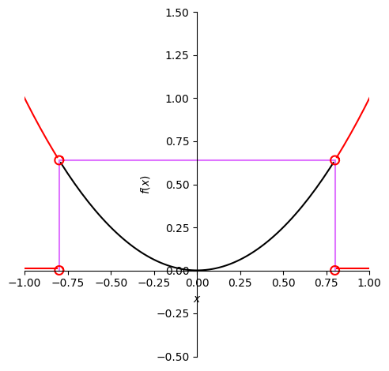

```python
import numpy as np
import sympy
from sympy.abc import a, b, c, x, y, z

def draw_circle(dx, dy, rx, ry=None, *, line_color='red'):
    if ry is None:
        ry = rx
    return sympy.plot_parametric((rx*sympy.cos(z) + dx, ry*sympy.sin(z) + dy), (z, 0, 7), line_color=line_color, show=False)

plot = sympy.plot(sympy.Piecewise(
    (x**2, abs(x) <= 4/5)
), xlim=(-1, 1), ylim=(-0.5, 1.5), aspect_ratio=(1, 1), show=False, line_color='black')
plot.append(sympy.plot(sympy.Piecewise(
    (x**2, abs(x) > 4/5)
), show=False, line_color='red')[0])
plot.append(sympy.plot(sympy.Piecewise(
    (0.01, abs(x) > 4/5)
), show=False, line_color='red')[0])
plot.append(sympy.plot(sympy.Piecewise(
    (16/25, abs(x) < 4/5)
), show=False, line_color='#df75ff')[0])
plot.append(sympy.plot_parametric((4/5, y), (y, 0, 16/25), show=False, line_color='#df75ff')[0])
plot.append(sympy.plot_parametric((-4/5, y), (y, 0, 16/25), show=False, line_color='#df75ff')[0])
plot.append(draw_circle(4/5, 0, 0.025)[0])
plot.append(draw_circle(-4/5, 0, 0.025)[0])
plot.append(draw_circle(4/5, 16/25, 0.025)[0])
plot.append(draw_circle(-4/5, 16/25, 0.025)[0])
plot.show()
```

## 2

$x^2 < \frac{25}{4} | \sqrt{.}$

$\Leftrightarrow |x| < \frac{5}{2}$

$\Leftrightarrow x < \frac{5}{2} \wedge -x < \frac{5}{2}$

$\Leftrightarrow -x < \frac{5}{2} \wedge x < \frac{5}{2}$

$\Leftrightarrow \frac{5}{2} > -x \wedge x < \frac{5}{2}$

$\Leftrightarrow -\frac{5}{2} < x \wedge x < \frac{5}{2}$

$\Leftrightarrow -\frac{5}{2} < x < \frac{5}{2}$

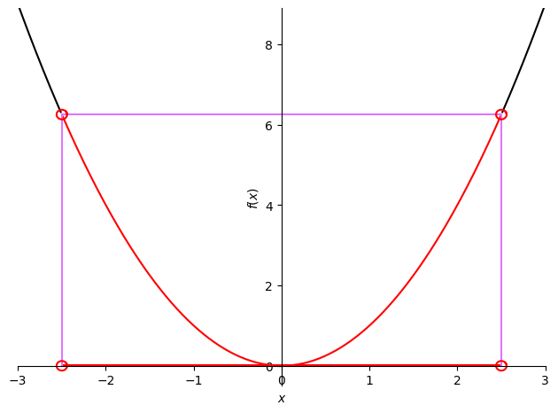

```python
plot = sympy.plot(sympy.Piecewise(
    (x**2, abs(x) >= 5/2)
), xlim=(-3, 3), ylim=(-0.5, 8.9), show=False, line_color='black')
plot.append(sympy.plot(sympy.Piecewise(
    (x**2, abs(x) < 5/2)
), show=False, line_color='red')[0])
plot.append(sympy.plot(sympy.Piecewise(
    (0.01, abs(x) < 5/2)
), show=False, line_color='red')[0])
plot.append(sympy.plot(sympy.Piecewise(
    (25/4, abs(x) < 5/2)
), show=False, line_color='#df75ff')[0])
plot.append(sympy.plot_parametric((5/2, y), (y, 0, 25/4), show=False, line_color='#df75ff')[0])
plot.append(sympy.plot_parametric((-5/2, y), (y, 0, 25/4), show=False, line_color='#df75ff')[0])
plot.append(draw_circle(5/2, 0, 0.06, 0.12)[0])
plot.append(draw_circle(-5/2, 0, 0.06, 0.12)[0])
plot.append(draw_circle(5/2, 25/4, 0.06, 0.12)[0])
plot.append(draw_circle(-5/2, 25/4, 0.06, 0.12)[0])
plot.show()
```

## 3

$(x-\frac{5}{6})^2 \geq \frac{49}{36} | \sqrt{.}$

$\Leftrightarrow |x-\frac{5}{6}| \geq \frac{7}{6}$

$\Leftrightarrow x-\frac{5}{6} \geq \frac{7}{6} \vee -(x-\frac{5}{6}) \geq \frac{7}{6}$

$\Leftrightarrow x \geq \frac{12}{6} \vee -x + \frac{5}{6} \geq \frac{7}{6}$

$\Leftrightarrow x \geq 2 \vee -x \geq \frac{2}{6}$

$\Leftrightarrow x \geq 2 \vee x \leq -\frac{1}{3}$

3

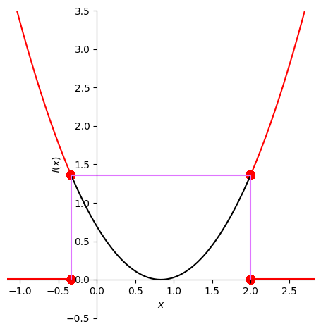

```python
def fill_circle(dx, dy, rx, ry=None, line_color='red'):
    if ry is None:
        ry = rx
    return sympy.plot_implicit((x - dx)**2/rx**2 + (y - dy)**2/ry**2 <= 1, line_color=line_color, show=False)

plot = sympy.plot(sympy.Piecewise(
    ((x-5/6)**2, abs(x-5/6) < 7/6)
), xlim=(5/6 - 2, 5/6 + 2), ylim=(-0.5, 3.5), aspect_ratio=(1, 1), show=False, line_color='black')
plot.append(sympy.plot(sympy.Piecewise(
    ((x-5/6)**2, abs(x-5/6) >= 7/6)
), show=False, line_color='red')[0])
plot.append(sympy.plot(sympy.Piecewise(
    (0.01, abs(x-5/6) >= 7/6)
), show=False, line_color='red')[0])
plot.append(sympy.plot(sympy.Piecewise(
    (49/36, abs(x-5/6) < 7/6)
), show=False, line_color='#df75ff')[0])
plot.append(sympy.plot_parametric((2, y), (y, 0, 49/36), show=False, line_color='#df75ff')[0])
plot.append(sympy.plot_parametric((-1/3, y), (y, 0, 49/36), show=False, line_color='#df75ff')[0])
plot.append(fill_circle(2, 0, 0.06)[0])
plot.append(fill_circle(-1/3, 0, 0.06)[0])
plot.append(fill_circle(2, 49/36, 0.06)[0])
plot.append(fill_circle(-1/3, 49/36, 0.06)[0])
plot.show()
```

## 4

$(x+3)^2 \leq \frac{36}{25} | \sqrt{.}$

$\Leftrightarrow |x+3| \leq \frac{6}{5}$

$\Leftrightarrow -\frac{6}{5} \leq x+3 \leq \frac{6}{5}| -3$

$\Leftrightarrow -\frac{6}{5} - \frac{5*3}{3} \leq x + 3 - 3 \leq \frac{6}{5} - \frac{5*3}{3}$

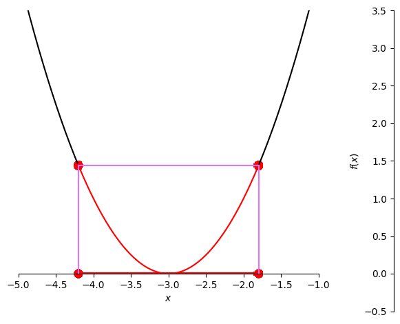

```python
plot = sympy.plot(sympy.Piecewise(
    ((x+3)**2, abs(x+3) > 6/5)
), xlim=(-3 - 2, -3 + 2), ylim=(-0.5, 3.5), aspect_ratio=(1, 1), show=False, line_color='black')
plot.append(sympy.plot(sympy.Piecewise(
    ((x+3)**2, abs(x+3) <= 6/5)
), show=False, line_color='red')[0])
plot.append(sympy.plot(sympy.Piecewise(
    (0.01, abs(x+3) <= 6/5)
), show=False, line_color='red')[0])
plot.append(sympy.plot(sympy.Piecewise(
    (36/25, abs(x+3) < 6/5)
), show=False, line_color='#df75ff')[0])
plot.append(sympy.plot_parametric((-9/5, y), (y, 0, 36/25), show=False, line_color='#df75ff')[0])
plot.append(sympy.plot_parametric((-21/5, y), (y, 0, 36/25), show=False, line_color='#df75ff')[0])
plot.append(fill_circle(-9/5, 0, 0.06)[0])
plot.append(fill_circle(-21/5, 0, 0.06)[0])
plot.append(fill_circle(-9/5, 36/25, 0.06)[0])
plot.append(fill_circle(-21/5, 36/25, 0.06)[0])
plot.show()
```

## 5

$u = 8 = 2(a + b)\Leftrightarrow 4 = a + b \Leftrightarrow a = 4 - b$

$a * b \geq 3,5$

$\Leftrightarrow (4 - b) * b \geq \frac{7}{2}$

$\Leftrightarrow 4b - b^2 \geq \frac{7}{2} | *(-1)$

$\Leftrightarrow b^2 - 4b \leq -\frac{7}{2}$

Mittels quadratischer Ergänzung

$\Leftrightarrow b^2 - 2b * 2 + 2^2 - 2^2 \leq -\frac{7}{2} | + 4$

$\Leftrightarrow (b - 2)^2 \leq \frac{1}{2} | \sqrt{.}$

$\Leftrightarrow |b - 2| \leq \sqrt{\frac{1}{2}}$

$\Leftrightarrow b - 2 \leq \sqrt{\frac{1}{2}} \wedge -(b - 2) \leq \sqrt{\frac{1}{2}}$

$\Leftrightarrow b - 2 \leq \sqrt{\frac{1}{2}} \wedge -b + 2 \leq \sqrt{\frac{1}{2}}$

$\Leftrightarrow b \leq \sqrt{\frac{1}{2}} + 2 \wedge -b \leq \sqrt{\frac{1}{2}} - 2$

$\Leftrightarrow b \leq \sqrt{\frac{1}{2}} + 2 \wedge b \geq -\sqrt{\frac{1}{2}} + 2$

$\Leftrightarrow b \leq \sqrt{\frac{1}{2}} + 2 \wedge -\sqrt{\frac{1}{2}} + 2 \leq b$

$\Leftrightarrow -\sqrt{\frac{1}{2}} + 2 \leq b \leq \sqrt{\frac{1}{2}} + 2$

Alle Werte für $b$ sind soweit möglich, da gilt: $0 < -\sqrt{\frac{1}{2}} + 2 \leq b \leq \sqrt{\frac{1}{2}} + 2 < 8$

Nun werden die dazu passenden Werte für $a$ bestimmt, indem die Grenzen in $a = 4 - b$ eingesetzt werden.

$4 - (-\sqrt{\frac{1}{2}} + 2)$

$= 4 + \sqrt{\frac{1}{2}} - 2$

$= 2 + \sqrt{\frac{1}{2}}$

bzw.

$4 - (\sqrt{\frac{1}{2}} + 2)$

$= 4 - \sqrt{\frac{1}{2}} - 2$

$= 2 - \sqrt{\frac{1}{2}}$

Es sind die gleichen Grenzen wie bei $b$. Dies ist nicht überraschend, da alle Berechnungen für $b$ auch für $a$ gelten.

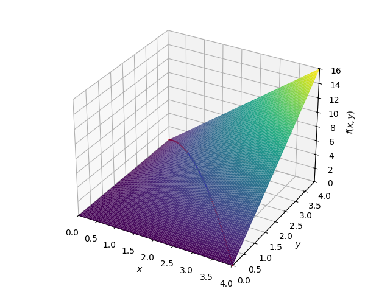

```python
%matplotlib widget
from sympy.plotting import plot3d, plot3d_parametric_line
plot = plot3d(
    x*y,
   #3.5+0.0001*x+0.0001*y,
    (x, 0, 4), (y, 0, 4), show=False)
plot.append(plot3d_parametric_line(x, 4-x, x*(4-x), (x, 0, 4), line_color='red', show=False)[0])
plot.append(plot3d_parametric_line(x, 4-x, x*(4-x), (x, 2 - math.sqrt(0.5), 2+math.sqrt(0.5)), line_color='blue', show=False)[0])
plot.show()
```

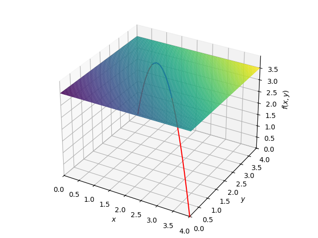

```python
%matplotlib widget
from sympy.plotting import plot3d, plot3d_parametric_line
plot = plot3d(
    #x*y,
    3.5+0.0001*x+0.0001*y,
    (x, 0, 4), (y, 0, 4), show=False)
plot.append(plot3d_parametric_line(x, 4-x, x*(4-x), (x, 0, 4), line_color='red', show=False)[0])
plot.append(plot3d_parametric_line(x, 4-x, x*(4-x), (x, 2 - math.sqrt(0.5), 2+math.sqrt(0.5)), line_color='blue', show=False)[0])
plot.show()
```

## 6

$x^2 + 3x < 0$

Mittels quadratischer Ergänzung

$x^2 + 2x * \frac{3}{2} + (\frac{3}{2})^2 - (\frac{3}{2})^2 < 0 | + (\frac{3}{2})^2$

$\Leftrightarrow (x + \frac{3}{2})^2 < (\frac{3}{2})^2 | \sqrt{.}$

$\Leftrightarrow |x + \frac{3}{2}| < \frac{3}{2}$

$\Leftrightarrow -\frac{3}{2} < x + \frac{3}{2} < \frac{3}{2} | - \frac{3}{2}$

$\Leftrightarrow -3 < x < 0 | - \frac{3}{2}$

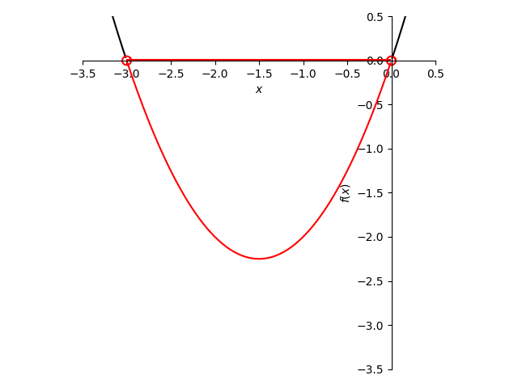

```python
plot = sympy.plot(sympy.Piecewise(
    (x**2 + 3*x, abs(x+3/2) >= 3/2)
), xlim=(-3.5, 0.5), ylim=(-3.5, 0.5), aspect_ratio=(1, 1), show=False, line_color='black')
plot.append(sympy.plot(sympy.Piecewise(
    (x**2 + 3*x, abs(x+3/2) < 3/2)
), show=False, line_color='red')[0])
plot.append(sympy.plot(sympy.Piecewise(
    (0.01, abs(x+3/2) < 3/2)
), show=False, line_color='red')[0])
plot.append(draw_circle(0, 0, 0.05)[0])
plot.append(draw_circle(-3, 0, 0.05)[0])
plot.show()
```

## 7

$9x^2 - 6x \geq 5$

Mittels quadratischer Ergänzung

$\Leftrightarrow 9x^2 - 2 * 3x + 1 - 1 \geq 5 | + 1$

$\Leftrightarrow (3x - 1)^2 \geq 6 | \sqrt{.}$

$\Leftrightarrow |3x - 1| \geq \sqrt{6}$

$\Leftrightarrow 3x - 1 \geq \sqrt{6} \vee -(3x - 1) \geq \sqrt{6}$

$\Leftrightarrow 3x - 1 \geq \sqrt{6} \vee -3x + 1 \geq \sqrt{6}$

$\Leftrightarrow 3x \geq \sqrt{6} + 1 \vee -3x \geq \sqrt{6} - 1$

$\Leftrightarrow x \geq \frac{1}{3} + \frac{1}{3}\sqrt{6} \vee x \leq \frac{1}{3} -\frac{1}{3}\sqrt{6}$

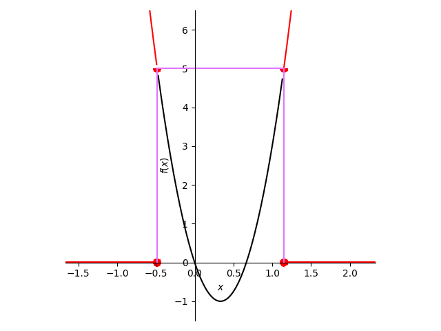

```python
plot = sympy.plot(sympy.Piecewise(
    (9*x**2 - 6*x, abs(x-1/3) < math.sqrt(6)/3)
), xlim=(1/3 - 2, 1/3 + 2), ylim=(-1.5, 6.5), aspect_ratio=(2, 1), show=False, line_color='black')
plot.append(sympy.plot(sympy.Piecewise(
    (9*x**2 - 6*x, abs(x-1/3) >= math.sqrt(6)/3)
), show=False, line_color='red')[0])
plot.append(sympy.plot(sympy.Piecewise(
    (0.01, abs(x-1/3) >= math.sqrt(6)/3)
), show=False, line_color='red')[0])
plot.append(sympy.plot(sympy.Piecewise(
    (5, abs(x-1/3) < math.sqrt(6)/3)
), show=False, line_color='#df75ff')[0])
plot.append(sympy.plot_parametric((1/3+math.sqrt(6)/3, y), (y, 0, 5), show=False, line_color='#df75ff')[0])
plot.append(sympy.plot_parametric((1/3-math.sqrt(6)/3, y), (y, 0, 5), show=False, line_color='#df75ff')[0])
plot.append(fill_circle(1/3+math.sqrt(6)/3, 0, 0.05, 0.1)[0])
plot.append(fill_circle(1/3-math.sqrt(6)/3, 0, 0.05, 0.1)[0])
plot.append(fill_circle(1/3+math.sqrt(6)/3, 5, 0.05, 0.1)[0])
plot.append(fill_circle(1/3-math.sqrt(6)/3, 5, 0.05, 0.1)[0])
plot.show()
```

## 8

$9x^2 - 6x + 1 > 0$

Mittels zweiter Binomischer Formel

$\Leftrightarrow (3x - 1)^2 > 0 | \ sqrt{.}$

$\Leftrightarrow |3x - 1| > 0$

$\Leftrightarrow 3x - 1 > 0 \vee -(3x - 1) > 0$

$\Leftrightarrow 3x - 1 > 0 \vee -3x + 1 > 0$

$\Leftrightarrow 3x > 1 \vee -3x > -1$

$\Leftrightarrow x > \frac{1}{3} \vee x < \frac{1}{3}$

$\Leftrightarrow x \neq \frac{1}{3}$

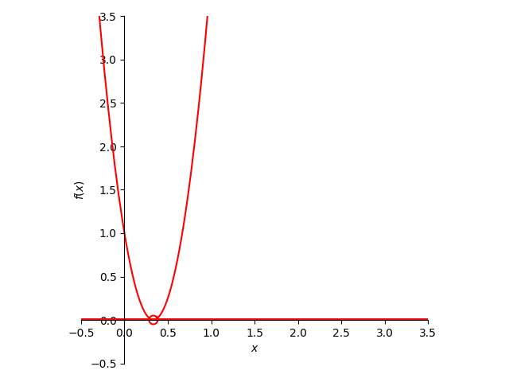

```python
plot = sympy.plot(sympy.Piecewise(
    (9*x**2 - 6*x + 1, abs(x-1/3) < math.sqrt(6)/3)
), xlim=(-0.5, 3.5), ylim=(-0.5, 3.5), aspect_ratio=(1, 1), show=False, line_color='red')
plot.append(sympy.plot(0.01, show=False, line_color='red')[0])
plot.append(draw_circle(1/3, 0, 0.05)[0])
plot.show()
```

## 9

$9x^2 - 6x + 1 \leq 0$

Alle Punkte der Parabel außer die von Aufgabe 8. Da bleibt nur $x = \frac{1}{3}$.

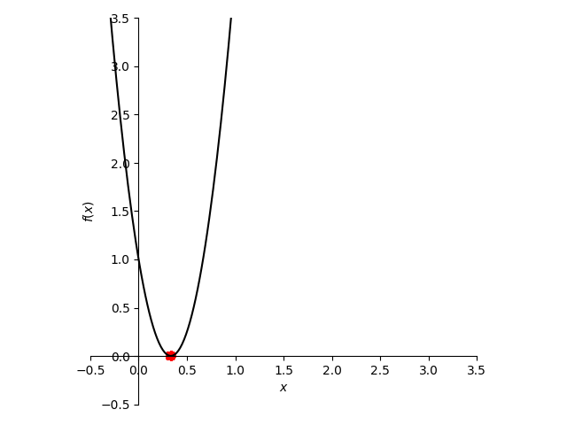

```python
plot = sympy.plot(sympy.Piecewise(
    (9*x**2 - 6*x + 1, abs(x-1/3) < math.sqrt(6)/3)
), xlim=(-0.5, 3.5), ylim=(-0.5, 3.5), aspect_ratio=(1, 1), show=False, line_color='black')
plot.append(fill_circle(1/3, 0, 0.05)[0])
plot.show()
```

## 10

$49x^2 - 42x + 5 < 0$

Mittels quadratischer Ergänzung

$\Leftrightarrow 49x^2 - 2 * 7x * 3 + 3^2 - 3^2 + 5 < 0 | + 4$

$\Leftrightarrow (7x - 3)^2 < 4 | \sqrt{.}$

$\Leftrightarrow |7x - 3| < 2$

$\Leftrightarrow -2 < 7x - 3 < 2$

$\Leftrightarrow 1 < 7x < 5$

$\Leftrightarrow \frac{1}{7} < x < \frac{5}{7}$

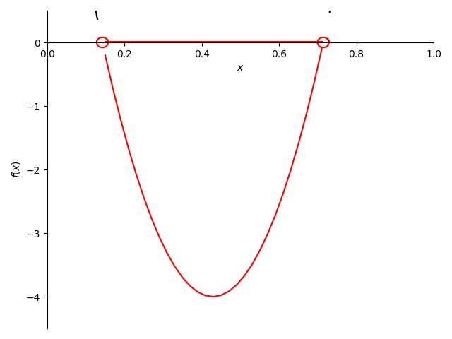

```python
plot = sympy.plot(sympy.Piecewise(
    (49*x**2-42*x+5, abs(x-3/7) >= 2/7)
), xlim=(0, 1), ylim=(-4.5, 0.5), aspect_ration=(4, 1), show=False, line_color='black')
plot.append(sympy.plot(sympy.Piecewise(
    (49*x**2-42*x+5, abs(x-3/7) < 2/7)
), show=False, line_color='red')[0])
plot.append(sympy.plot(sympy.Piecewise(
    (0.01, abs(x-3/7) < 2/7)
), show=False, line_color='red')[0])
plot.append(draw_circle(1/7, 0, 0.015, 0.08)[0])
plot.append(draw_circle(5/7, 0, 0.015, 0.08)[0])
plot.show()
```